# Impact des Diagnostics de Performance Énergétique (DPE)

WALMSLEY_MENARD_PICARD_LAMBERT

30 avril 2024

[figure not shown]

Voici ci-dessous le dossier zip contenant tous les fichiers nécessaires au code :

https://drive.google.com/drive/folders/15nMGgUi9QFOt2exKOUP0JRpKvf8eXBqT?usp=drive_link

## Présentation du sujet

Notre but est d’évaluer l’impact de la classe de Diagnostic de Performance Energétique (DPE) sur les consommations électriques de logements et confronter les estimations issues des DPE à des mesures réelles.  
Plus précisément, l’objectif est de donner des pistes de décisions de rénovations en quantifiant l’impact d’une amélioration de DPE (qui peut en particulier être liée à des travaux de rénovation) sur les consommations électriques.

On souhaite répondre à l’une et/ou l’autre des deux questions suivantes :

- Combien gagne-t-on sur ses factures d’électricité (en kWh / an, voire en euros par an en prenant des hypothèses tarifaires) à passer d’une classe de DPE à une autre (ex : de G à F, ou de F à E, la valeur recherchée dépendant des classes concernées) ?
- Les estimations conventionnelles fournies dans les DPE reflètent-elles bien la réalité mesurée des consommations électriques (c’est-à-dire qu’en moyenne, pour différents types de bâtiments, la consommation mesurée est-elle proche de la consommation prédite par le DPE) ? Et quelle est la variabilité restante due à l’hétérogénéité des modes de vie et taux d’occupation (écart type entre la consommation mesurée et la consommation prédite par le DPE, pour différents types de logements) ?  
  Enfin, d’autres questions complémentaires pourront également être adressées :
- Détailler le gain de consommation dû à un changement de classe de DPE par usage : chauffage, eau chaude sanitaire, refroidissement, éclairage, autres (ces détails sont présents dans les données de DPE) ;
- Etudier l’impact des caractéristiques du bâtiment ou des équipements (du mode de chauffage, de l’isolation, de l’année de construction, etc…) sur la consommation électrique.

Dans notre cas, nous avons choisi d’analyser l’impact des caractéristiques du bâtiment mais aussi les consommations réelles des logements dans les différentes classes.

Pour cela, nous avons détaillé l’étude en plusieurs points :

#### Sommaire

1. Comparer son type de bien et se positionner par rapport à d’autres logements français selon le DPE
2. Comment l’énergie se perd et quels sont les moyens d’actions simples ?
3. Lien entre consommations et DPE

Les données proviennent de la base de données de l’Ademe, “DPE Logements existants (depuis juillet 2021)”

## 2. Comparer son type de bien et se positionner par rapport à d’autres logements français selon le DPE

L’ensemble de cette partie est basé sur des logements :  
- datant des années supérieures à 1800,  
- ayant une surface de logement renseignée,  
- avec un coût total également renseigné des 5 usages : eau chaude sanitaire, chauffage, climatisation, eclairage et les usages auxiliaires (déduit de la production pv autoconsommée).  
Plus précisemment, les 2 derniers graphiques sont restreints pour des surfaces d’habitation des appartements inférieure à 5 000 m² et les logements ayant renseignés leur positionnement au sein de l’immeuble. En effet, nous avons jugé que des appartements ayant une surface supérieures à 5 000 m² ne sont pas représentatifs de la taille de ce type de logement et pourraient ainsi avoir un trop grand impact sur les moyennes calculées.

### a. Comparaison des coûts entre une maison, un immeuble et un appartement

Voici la représentation visuelle des moyennes des coûts en fonction du type d’habitation et de sa classe DPE :

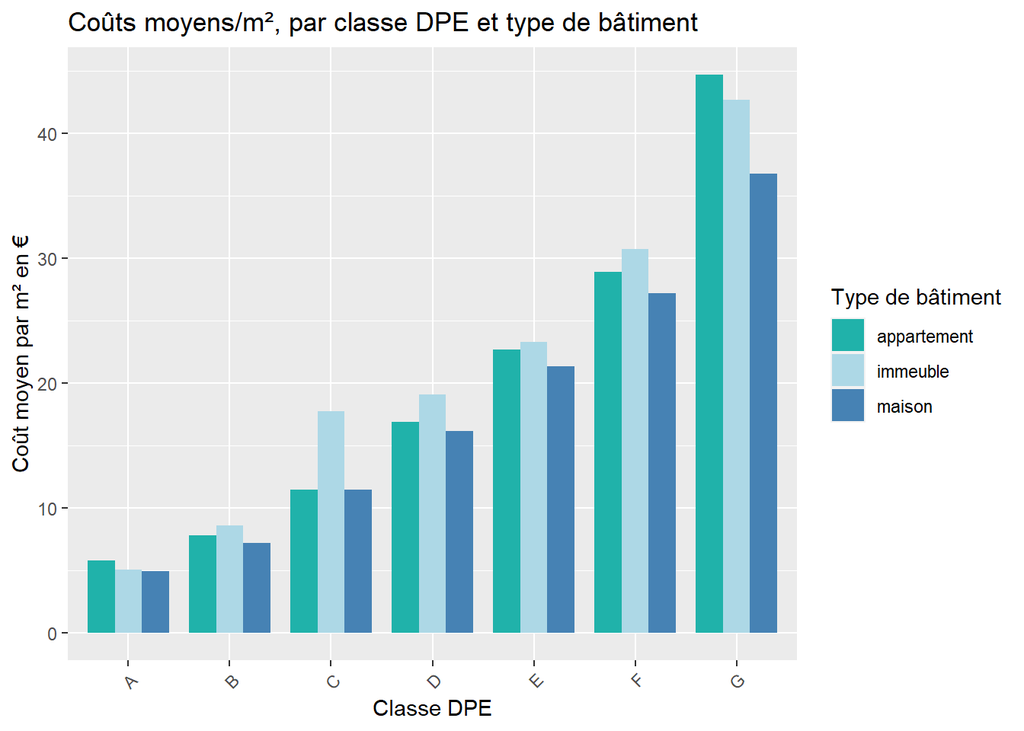

Si l’on souhaite regarder seuleument la différence entre maison et appartement :

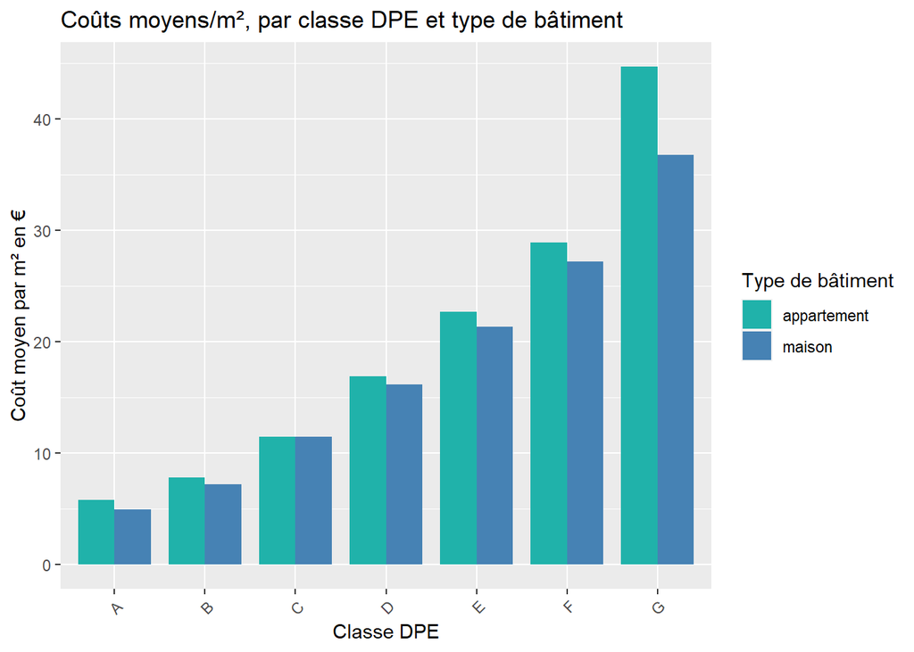

Dans ces 2 graphiques, nous remarquons que le coût moyen par mètre carré est légérement plus cher pour un appartememnt plutôt qu’une maison, toutes classes de DPE confondues. Une des raisons peut être un nombre de personnes plus important au metre carré dans un appartement que dans une maison ce que augmente la consommation. En effet, les appartements sont souvent situés dans les centres-villes et donc un choix des personnes à vouloir vivre à proximité de leur travail et quartier de vie à défaut d’une surface de logement plus grande avec le même nombre de personne.

Une deuxième raison pourrait venir du type de systèmes de chauffage et de refroidissement. Si ces derniers sont centralisés à l’ensemble de l’immeuble, cela peut entraîner une utilisation plus intensive de l’énergie, surtout si les réglages de température ne sont pas personnalisables pour chaque logement.

Enfin, une dernière possibilité serait liée au fait qu’un logement même bien isolé, ne peut gérer l’isolation de ses voisins. Par conséquent, malgré leur effort si leurs voisins ne souhaitent pas isoler leurs murs, ils laisseront passer plus de déperditions thermiques à l’habitant concerné.

### b. Comparaison des appartements en fonction de leur position dans l’immeuble

Le but ici est cette fois-ci de comparer les différences de coût entre un appartement au rez-de-chaussée, à un étage intermédiaire ou au dernier étage :

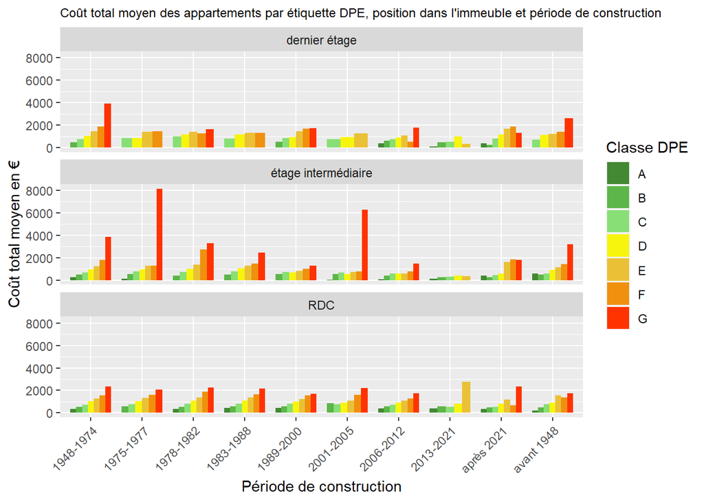

Si l’on compare maintenant les 3 types, les logements situés sur un étage intermédiaire, ont un coût plus élevé. L’hypothèse 2 donnée en conclusion du précédent graphique peut s’avérer être une cause. De plus, il faut prendre en compte l’éclairage qui dépend de la luminosité dans le logement. Un appartement en rez-de-chaussé aura moins de lumière soit un besoin en éclairage plus important en hiver et moins de climatisation (si le logement possède ce système) en été. A l’inverse, des étages supérieurs. Les appartements situés aux étages intermédiaires, quant à eux, peuvent être plus susceptibles d’accumuler de la chaleur provenant des appartements situés en dessous et au-dessus.

Nous remarquons également que plus la maison a été construite récemment et plus les coûts diminuent sauf pour les classes G. La société prend de plus en plus en conséidération l’isolement dès la construction.

Ce graphique permet bien d’illustrer en tout cas, le gain possible par un changement de classe DPE quelque soit la position de son logement.

### c. Lien avec les déperditions

Afin de valider ou non nos hypothèses liées aux déperditions, voici un graphique représentant la comparaison du coût moyen des appartements en fonction de leur positionnement dans l’immeuble et de leur déperdition thermique :

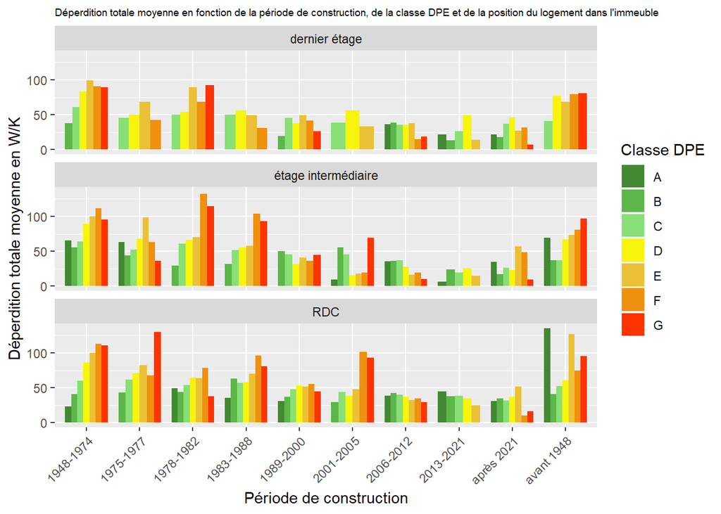

Nous comprenons ici que malgré le fait que la corrélation soit moins linéaire entre les différentes classes de DPE que sur le graphique précédent, plus le logement a une classe DPE faible et plus sa déperdition est forte.

La différence dans l’isolation thermique dès la construction est ici très visible et l’on remarque une nette diminution à partir des années 2000.

De ce fait, changer de classe DPE peut avoir de réels impacts sur les factures à la fin du mois mais aussi sur le bien être dans le logement. Effectivement, les appartements mieux isolés et plus économes en énergie peuvent offrir un environnement intérieur plus confortable, avec des températures plus stables et une meilleure qualité de l’air, ce qui contribue au bien-être et au confort des résidents.

## 2. Comment l’énergie se perd et quels sont les moyens d’actions simples ?

Préambule : certains des graphiques de cette partie utiliseront des catégories de zone climatique. Voici une carte représentative de ces différentes zones.

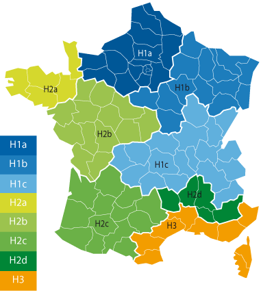

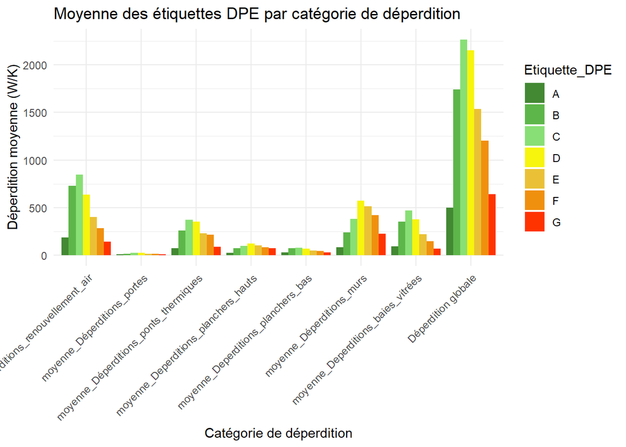

Dans ce premier graphique, nous pouvons voir que les logements avec les plus grandes déperditions ne sont pas celles avec les étiquettes les plus basses contrairement à ce l’on pourrait penser. En effet, on peut remarquer qui ce sont les étiquettes C et D qui ont les plus grandes valeurs. De plus, ce graphique permet de voir que les pertes thermiques proviennent d’abord du renouvellement d’air, très important sur les logements B et C et puis à travers les murs et les baies vitrées.

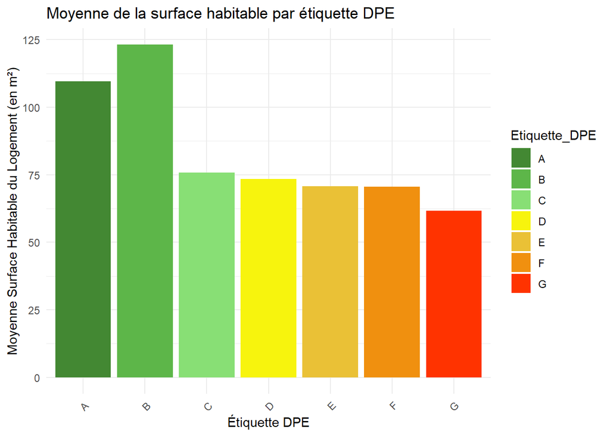

Ce deuxième graphique a été mis en place afin de prouver que les pics vu précédemment ne proviennent pas d’une surface plus importante. Nous pouvons voir qu’il y a très peu de changement de surface moyenne entre les logements à étiquettes C et D et celles inférieures. Nous remarquons tout de même une surface plus conséquente pour les étiquettes A et B.

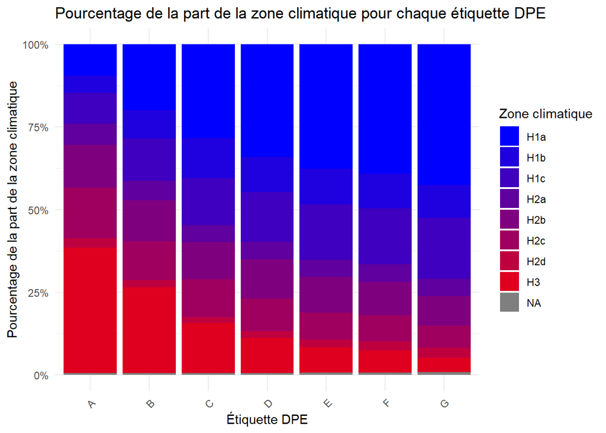

Pour approfondir l’étude, nous avons comparé la part des étiquettes sur les différentes zones géographiques de la métropole. Plus la couleur est rouge, plus la zone géographique est favorable à des températures plus clémentes. Ce graphique a été ajouté afin de voir la part des zones pour les différentes étiquettes ainsi que de savoir si les étiquettes C et D sont plus exposées au froid. Malheureusement, la seule information que nous pouvons tirer est que les zones plus chaudes présentent davantage de logements mieux isolés. Cela peut être justifié par des zones regroupant des propriétaires ayant plus de moyens financiers. En revanche, dans les zones plus exposées au froid, il y a une part plus importante de logement avec une étiquette désavantageuse.

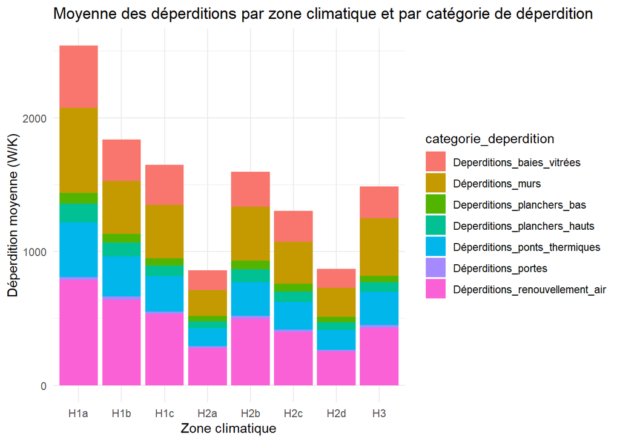

Pour compléter l’analyse des différences suivant le lieu d’habitation, nous aperçevons ici que les déperditions sont plus importantes sur les trois premières zones climatiques, présentes dans les zones plus exposées au froid avec des logements moins isolés comme peut le justifier le graphique précédent.

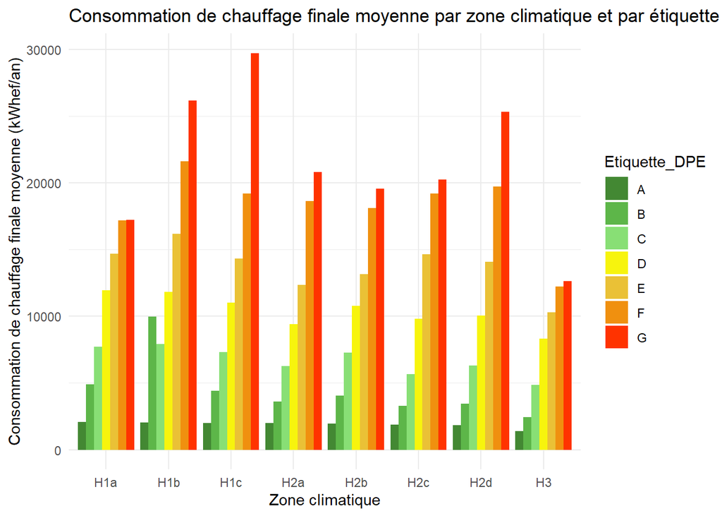

Enfin, voici un dernier graphique afin de conclure cette partie. Ce dernier suit la logique que plus un logement est consommateur, moins l’étiquette DPE est correcte. Par rapport aux zones géographiques, les pointes sont situées en H1B, C et H2D (du Pays-de-la-loire jusqu’au centre Est de la France en passant par l’Auvergne). En contraste avec le graphique précédent, nous constatons que les déperditions ne sont pas en accord avec la consommation. Afin de connaître l’origine de cette disparité, il faut étudier d’autres caractéristiques intrinsèques du logement.

## 3. Lien entre consommations et DPE

### a. Emission par année

Dans un premier temps, nous examinerons les principaux postes de consommation en kWhef/an par tranche de 20 ans, pour des constructions de 1900 à 2019, afin de déterminer s’ils sont liés au critère DPE.

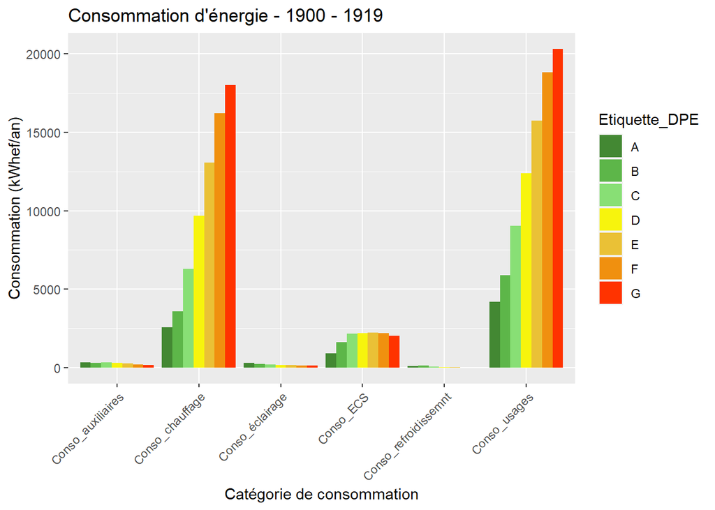

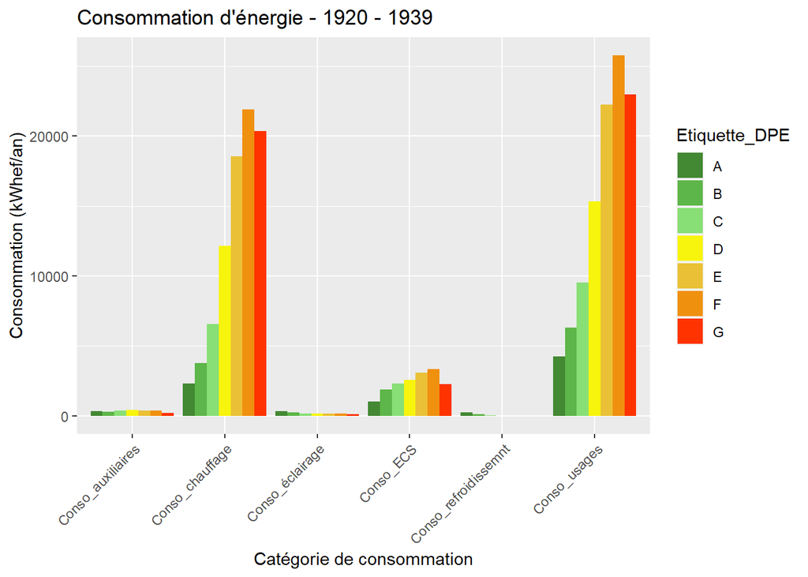

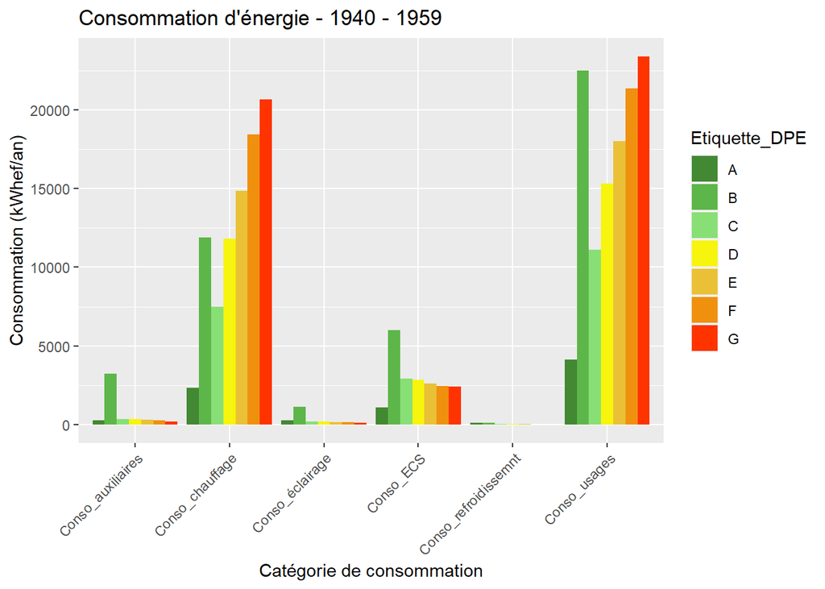

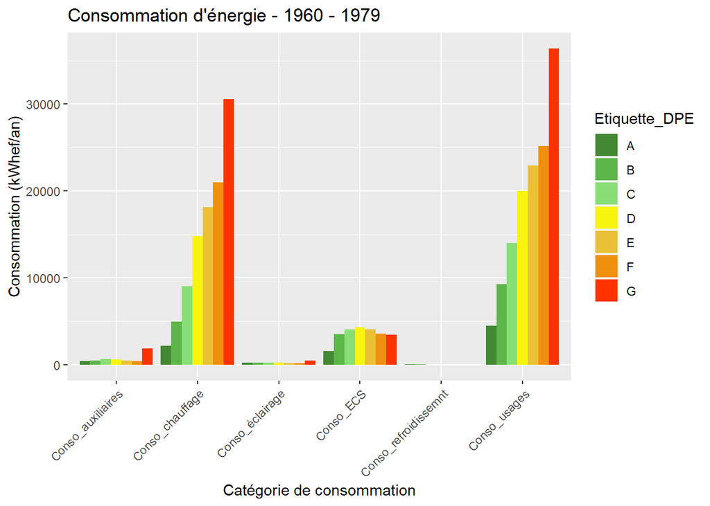

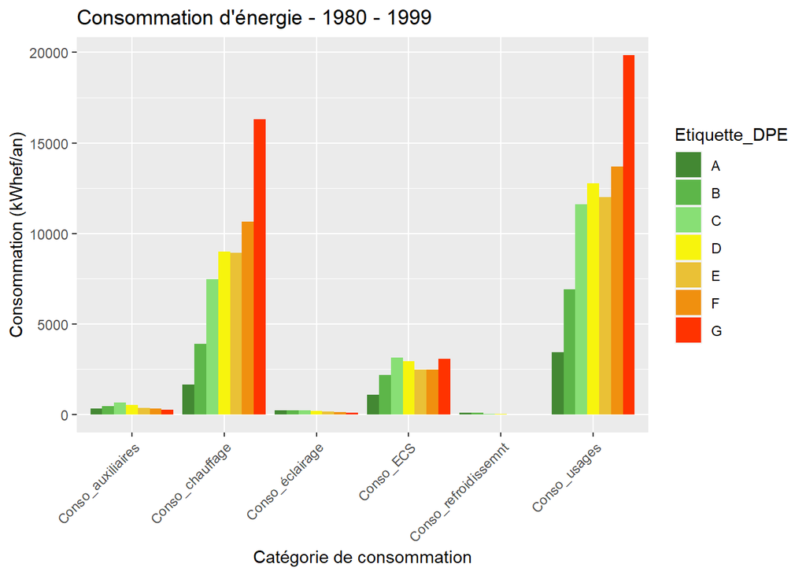

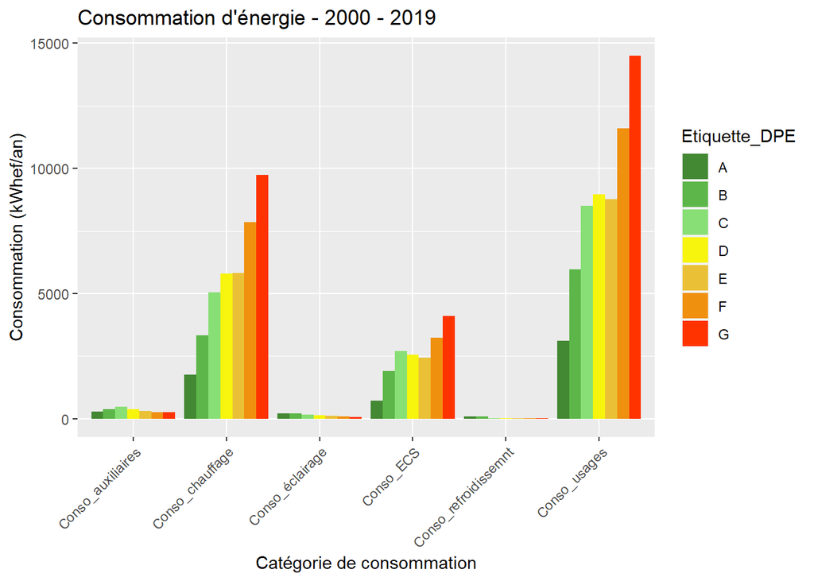

En ce qui concerne les spécificités :

• De 1920 à 1939, une observation intéressante émerge, montrant une consommation du DPE F supérieure à celle du DPE G pour le chauffage et l’ECS.

• Dans la décennie 1940-1959, il semble y avoir une anomalie affectant tous les postes de consommation pour le DPE B.

Dans les cas généraux :

La consommation auxiliaire semble ne pas présenter de corrélation claire avec les années ou les DPE. Pour ce qui est de l’ECS, on observe généralement une augmentation de A à C, suivie fréquemment d’une stagnation après le DPE C.

Malgré cela, les données suivent une certaine logique, avec une consommation d’usage plus faible en DPE A et plus élevée en DPE G, accompagnée d’une baisse significative au fil des ans, passant d’environ 12 000 kWhef/an dans les années 1900-1920 à environ 8 000 kWhef/an pour la période 2000-2019.

L’analyse de la moyenne des DPE par consommation consiste à examiner comment la performance énergétique des bâtiments, évaluée par les étiquettes DPE, varie en fonction de différentes catégories de consommation, telles que le chauffage, l’éclairage, etc.

Cette analyse nous permet de comprendre comment la performance énergétique des bâtiments diffère selon les différentes utilisations de l’énergie. Cela peut nous aider à identifier les domaines où des améliorations sont nécessaires et à concevoir des stratégies pour optimiser l’efficacité énergétique des bâtiments. Ce graphique fera disparaître les anomalies présentes avec les décades.

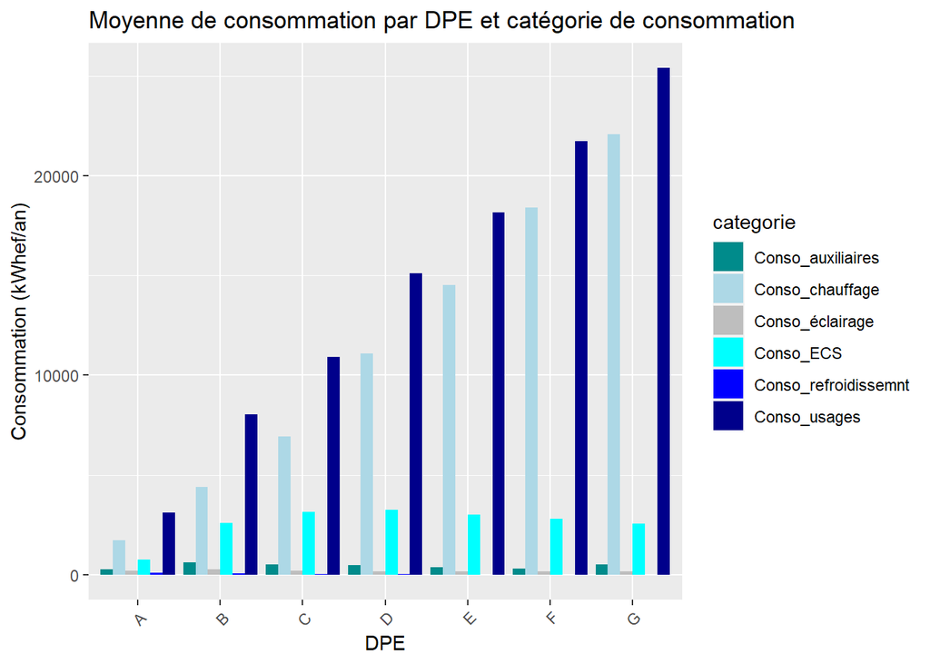

Nous constatons que la consommation d’usage (la somme de toutes les consommations) est parfaitement linéaire en fonction des étiquettes DPE. Le chauffage et l’ECS restent les postes de consommation les plus importants, avec une consommation de chauffage qui augmente de manière linéaire, tandis que la consommation d’ECS stagne après le DPE C. Les autres sources de consommation restent quant à elles marginales.

L’analyse du total des émissions de consommation pour différentes années permet de voir si les changements de politiques permettent effectivement de répondre aux exigences pour baisser la consommation des habitations. On évalue la somme des consommations provenant de diverses sources de consommation, telles que le chauffage, l’éclairage, etc., pour chaque année.

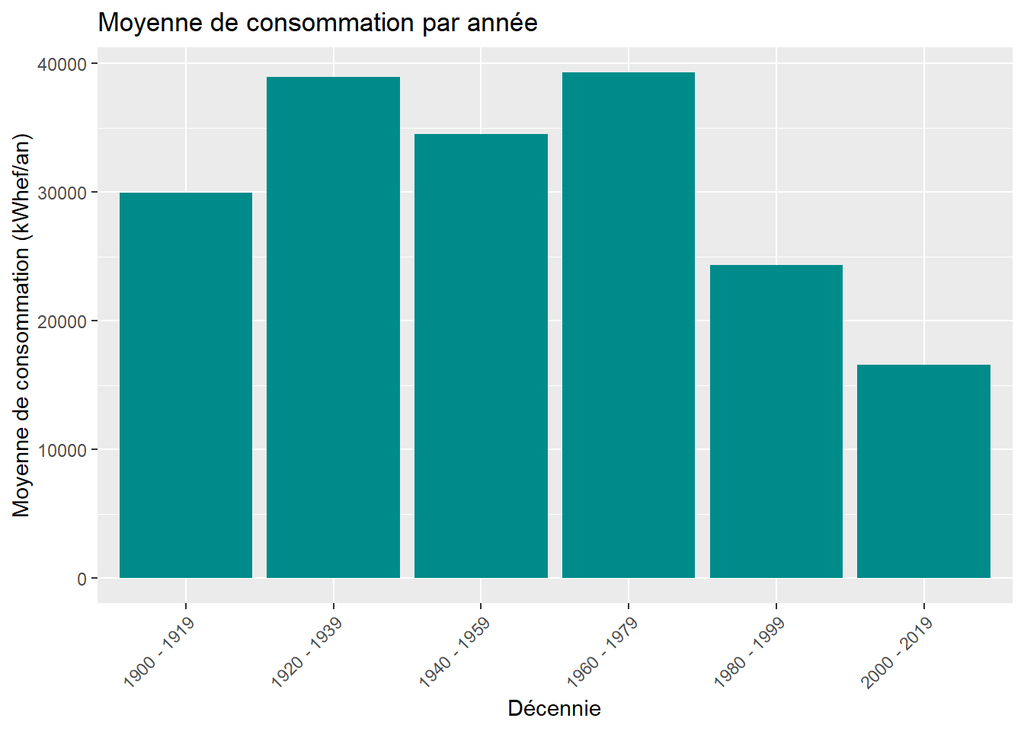

Depuis les années 1960, nous constatons une nette diminution de la consommation énergétique des habitations, avec une réduction d’environ la moitié de la consommation globale. Avant cette période, les maisons ne présentent pas de tendance ou de conjoncture claire en ce qui concerne leur consommation énergétique.

### d. GES/m² en fonction des DPE

L’analyse des émissions de gaz à effet de serre par mètre carré en fonction des étiquettes DPE permet de comprendre comment les performances énergétiques des bâtiments influent sur leurs émissions de gaz à effet de serre. Cette corrélation souligne l’importance des pratiques de construction et de rénovation durables pour réduire l’empreinte carbone des bâtiments et contribuer à la lutte contre le changement climatique.

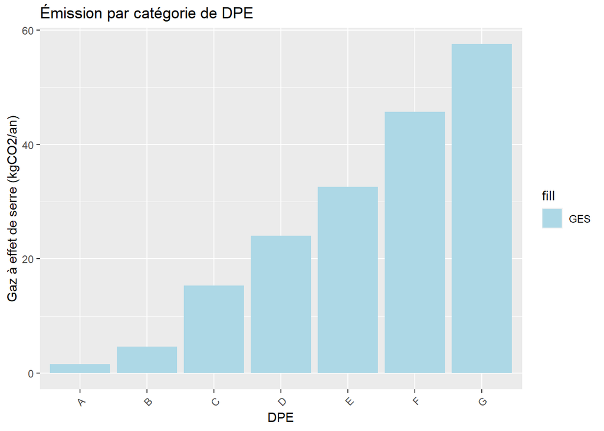